# Week 2 Take Home Lab

Sam Fritz-Schreck

2024-01-09

### Introduction

In this lab, you’ll use the techniques we studied this week to perform two analyses that have application in a military/DoD context:

- A “market basket” analysis to determine factors that are often associated with items of interest (in a military context this might be Soldier suicides or Traumatic Brain Injuries, known as TBI)

We will use some open source datasets as a proxy for data seen in these military problems.

Before beginning the lab below, use the RStudio IDE file management pane (lower right quadrant) to upload the titanic.raw.rdata folder onto your Rstudio instance.

#### Market Basket Analysis

The rdata file named titanic.raw.rdata is an R Workspace file that contains saved R objects (in this case a dataframe containing information about passengers aboard the Titanic).

1. Import the R workspace file named titanic.raw by using the following menu options in the RStudio IDE: Session -> Load Workspace. Then select the titanic.raw.rdata file.
2. Take a look at data you have loaded (use the command below to see the first few lines; use the data viewer in the top-right corner of the IDE to see all the data). This is simply a dataframe that contains categorical information about each person aboard the Titanic on the night it sunk, to include whether or not they survived.

```r
load("titanic.raw.rdata")
head(titanic.raw)
```

```
##   Class  Sex   Age Survived
## 1   3rd Male Child       No
## 2   3rd Male Child       No
## 3   3rd Male Child       No
## 4   3rd Male Child       No
## 5   3rd Male Child       No
## 6   3rd Male Child       No
```

3. Convert the dataframe into a transactions data type for use with the arules R package.

```r
library(arules)
class(data)
```

```
## [1] "function"
```

```r
titanic.data<-as(titanic.raw, "transactions")
```

4. Use the arules R package for Association Rule Mining (ARM) to analyze survival rates for people on the Titanic. Develop a unique set of rules that describe survival and death rates.

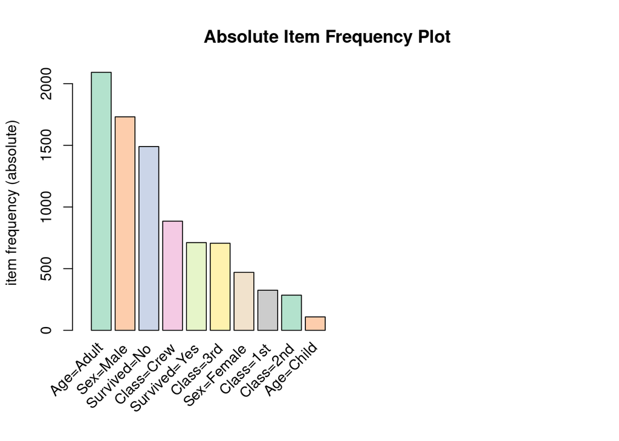

```r
itemFrequencyPlot(titanic.data,topN=20,type="absolute",col=brewer.pal(8,'Pastel2'), main="Absolute Item Frequency Plot")
```

```r
# Min Support as 0.001, confidence as 0.8.
association.rules <- apriori(titanic.data, parameter = list(supp=0.001, conf=0.8), appearance = list(default = "lhs", rhs=c("Survived=Yes","Survived=No")))
```

```
## Apriori
##
## Parameter specification:
##  confidence minval smax arem  aval originalSupport maxtime support minlen
##         0.8    0.1    1 none FALSE            TRUE       5   0.001      1
##  maxlen target  ext
##      10  rules TRUE
##
## Algorithmic control:
##  filter tree heap memopt load sort verbose
##     0.1 TRUE TRUE  FALSE TRUE    2    TRUE
##
## Absolute minimum support count: 2
##
## set item appearances ...[2 item(s)] done [0.00s].
## set transactions ...[10 item(s), 2201 transaction(s)] done [0.00s].
## sorting and recoding items ... [10 item(s)] done [0.00s].
## creating transaction tree ... done [0.00s].
## checking subsets of size 1 2 3 4 done [0.00s].
## writing ... [15 rule(s)] done [0.00s].
## creating S4 object  ... done [0.00s].
```

```r
summary(association.rules)
```

```
## set of 15 rules
##
## rule length distribution (lhs + rhs):sizes
## 3 4
## 7 8
##
##    Min. 1st Qu.  Median    Mean 3rd Qu.    Max.
##   3.000   3.000   4.000   3.533   4.000   4.000
##
## summary of quality measures:
##     support           confidence        coverage             lift
##  Min.   :0.002272   Min.   :0.8275   Min.   :0.002272   Min.   :1.222
##  1st Qu.:0.007497   1st Qu.:0.8650   1st Qu.:0.008178   1st Qu.:2.008
##  Median :0.036347   Median :0.9167   Median :0.042254   Median :2.716
##  Mean   :0.050583   Mean   :0.9242   Mean   :0.057913   Mean   :2.490
##  3rd Qu.:0.067015   3rd Qu.:1.0000   3rd Qu.:0.071104   3rd Qu.:3.096
##  Max.   :0.191731   Max.   :1.0000   Max.   :0.231713   Max.   :3.096
##      count
##  Min.   :  5.0
##  1st Qu.: 16.5
##  Median : 80.0
##  Mean   :111.3
##  3rd Qu.:147.5
##  Max.   :422.0
##
## mining info:
##          data ntransactions support confidence
##  titanic.data          2201   0.001        0.8
##                                                                                                                                                  call
##  apriori(data = titanic.data, parameter = list(supp = 0.001, conf = 0.8), appearance = list(default = "lhs", rhs = c("Survived=Yes", "Survived=No")))
```

```r
inspect(association.rules)
```

```
##      lhs                                    rhs            support
## [1]  {Class=2nd, Age=Child}              => {Survived=Yes} 0.010904134
## [2]  {Class=1st, Age=Child}              => {Survived=Yes} 0.002726034
## [3]  {Class=2nd, Sex=Female}             => {Survived=Yes} 0.042253521
## [4]  {Class=2nd, Sex=Male}               => {Survived=No}  0.069968196
## [5]  {Class=1st, Sex=Female}             => {Survived=Yes} 0.064061790
## [6]  {Class=Crew, Sex=Female}            => {Survived=Yes} 0.009086779
## [7]  {Class=3rd, Sex=Male}               => {Survived=No}  0.191731031
## [8]  {Class=2nd, Sex=Female, Age=Child}  => {Survived=Yes} 0.005906406
## [9]  {Class=2nd, Sex=Male, Age=Child}    => {Survived=Yes} 0.004997728
## [10] {Class=1st, Sex=Male, Age=Child}    => {Survived=Yes} 0.002271695
## [11] {Class=2nd, Sex=Female, Age=Adult}  => {Survived=Yes} 0.036347115
## [12] {Class=2nd, Sex=Male, Age=Adult}    => {Survived=No}  0.069968196
## [13] {Class=1st, Sex=Female, Age=Adult}  => {Survived=Yes} 0.063607451
## [14] {Class=Crew, Sex=Female, Age=Adult} => {Survived=Yes} 0.009086779
```

[output cut: 17 more lines]

```
## To reduce overplotting, jitter is added! Use jitter = 0 to prevent jitter.
```

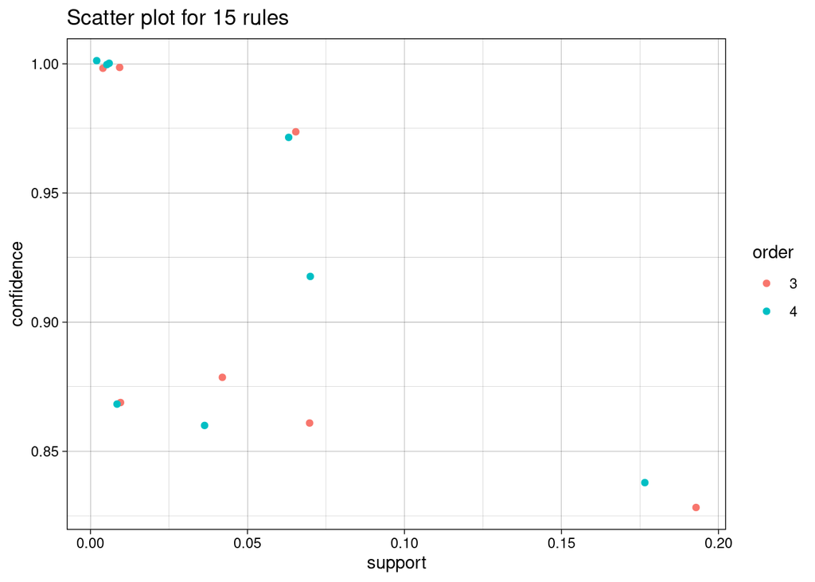

```r
# Filter rules with confidence greater than 0.4 or 40%
subRules<-association.rules[quality(association.rules)$confidence>0.4]

plot(subRules,method="two-key plot")
```

```r
subRules <- head(subRules, n = 15, by = "confidence")

plot(association.rules, method = "graph",  engine = "htmlwidget")
```

[interactive chart not shown]

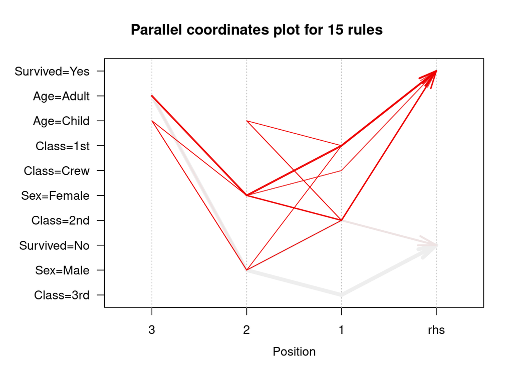

```r
# Filter top 20 rules with highest lift
subRules2<-head(subRules, n=20, by="lift")
plot(subRules2, method="paracoord")
```

5. Refer to the “arulesViz: Interactive Visualization of Association Rules with R” reading assignment you completed for this week’s lecture. Use the arulesVIz R package to build the different visualizations illustrated in these documents. Which one of these visualizations do you think is best used to desribe what happened in the Titanic disaster?

### Market Basket Lab Submission

##### For your consolidated lab submssion, you will need provide the following products and answers to the following questions:

1. Provide a neat and organized table (sorted in the order you think is most appropriate) that illustrates the set of association rules you’ve developed to describe survival (or not) in the Titanic disaster. Briefly describe why you feel this order is most appropriate?

```r
# Set options for displaying data frames in markdown
options(
  knitr.table.format = "html",  # Use HTML format for tables
  max.print = 100,               # Set the maximum number of rows to display
  width = 1000                   # Set the width of each column
)

rules.df = as(association.rules, "data.frame")

# Create an order vector based on whether the first column ends with "{Survived=No}"
order_vector <- order(grepl("\\{Survived=No\\}$", rules.df[, 1]), rules.df[,3])

# Reverse the order
order_vector <- rev(order_vector)

# Reorder the data frame
rules_sorted <- rules.df[order_vector, ]

# Display the sorted data frame
print(rules_sorted)
```

```
##                                                  rules     support confidence    coverage     lift count
## 12     {Class=2nd,Sex=Male,Age=Adult} => {Survived=No} 0.069968196  0.9166667 0.076328941 1.354083   154
## 4                {Class=2nd,Sex=Male} => {Survived=No} 0.069968196  0.8603352 0.081326670 1.270871   154
## 15     {Class=3rd,Sex=Male,Age=Adult} => {Survived=No} 0.175829169  0.8376623 0.209904589 1.237379   387
## 7                {Class=3rd,Sex=Male} => {Survived=No} 0.191731031  0.8274510 0.231712858 1.222295   422
## 10    {Class=1st,Sex=Male,Age=Child} => {Survived=Yes} 0.002271695  1.0000000 0.002271695 3.095640     5
## 9     {Class=2nd,Sex=Male,Age=Child} => {Survived=Yes} 0.004997728  1.0000000 0.004997728 3.095640    11
## 8   {Class=2nd,Sex=Female,Age=Child} => {Survived=Yes} 0.005906406  1.0000000 0.005906406 3.095640    13
## 2              {Class=1st,Age=Child} => {Survived=Yes} 0.002726034  1.0000000 0.002726034 3.095640     6
## 1              {Class=2nd,Age=Child} => {Survived=Yes} 0.010904134  1.0000000 0.010904134 3.095640    24
## 5             {Class=1st,Sex=Female} => {Survived=Yes} 0.064061790  0.9724138 0.065879146 3.010243   141
## 13  {Class=1st,Sex=Female,Age=Adult} => {Survived=Yes} 0.063607451  0.9722222 0.065424807 3.009650   140
## 3             {Class=2nd,Sex=Female} => {Survived=Yes} 0.042253521  0.8773585 0.048159927 2.715986    93
## 14 {Class=Crew,Sex=Female,Age=Adult} => {Survived=Yes} 0.009086779  0.8695652 0.010449796 2.691861    20
## 6            {Class=Crew,Sex=Female} => {Survived=Yes} 0.009086779  0.8695652 0.010449796 2.691861    20
## 11  {Class=2nd,Sex=Female,Age=Adult} => {Survived=Yes} 0.036347115  0.8602151 0.042253521 2.662916    80
```

2. Provide the visualization that you think is best used to explain the association rules for survival and death in the Titanic disaster. You may provide more than one visualization if you choose. The goal is to provide a visual description for what happened.

```r
plot(association.rules, method = "graph",  engine = "htmlwidget")
```

[interactive chart not shown]

3. Write a brief paragraph that references your visualization and the association rules table developed above to explain factors associated with both survival and death during the Titanic disaster (and note that this approach could easily be applied to many binary outcomes in the DoD such as Soldier suicide, casualty rates, etc.). This brief writeup should be worded in a way that would be appropriate for briefing a senior leader on the analysis of some phenomenon of interest in the DoD.